# INF385T Group Theta - Milestone 3

Authors

Juichien Chen

Siddharth Dhaka

Kylie Heitzenrater

Sharon Lobo

Published

April 8, 2025

# Intro

This document outlines our creation of a chatbot using the Tiny Shakespeare dataset. The chatbot answers questions in a Shakespearean style, utilizing the Retrieval Augmented Generation (RAG) pipeline and OpenAI’s GPT-3.5 turbo model.

# Data Card Information

The dataset used for this project is the Tiny Shakespeare dataset, which contains 40,000 lines of text from various Shakespearean plays.

- **URL**: [Tiny Shakespeare on HuggingFace](https://huggingface.co/datasets/karpathy/tiny_shakespeare)
- **Source**: Karpathy, Andrej
- **Repository**: HuggingFace
- **Task**: Question Answering
- **Size**: 40,000 lines
- **Structure**: Split into training, validation, and test sets
- **Additional Information**: The dataset is commonly used for character modeling and sequence prediction tasks.

# Data Dictionary

Here is the data dictionary for the Tiny Shakespeare dataset:

| Column Name | Description | Type | Units | Example |
| --- | --- | --- | --- | --- |
| text | A single line of text from Shakespeare’s plays | string | N/A | “Now is the winter of our discontent” |

# Steps to Create the Chatbot

## 1. **Dataset Selection**:

We chose the Tiny Shakespeare dataset after reviewing multiple options. The dataset contains 40,000 lines of text from various Shakespearean plays, making it ideal for our task of generating Shakespearean-style responses.

## 3. **Model Selection**:

Initially, we attempted to build the chatbot using Haystack. However, the bot did not use our dataset correctly for answering prompts. As a result, we pivoted to a Retrieval Augmented Generation (RAG) approach using OpenAI’s GPT-3.5 turbo model, which allowed us to better process and respond with Shakespearean-style text.

## 4. **Challenges and Adjustments**:

- **Haystack Issues**: The Haystack bot failed to use the dataset correctly when answering queries, and the preprocessing for dataset substitution caused issues that broke the bot.

Initially attempted to build the chatbot using the `haystack01` file provided to us. It took some minor reworking of the code to accommodate the columns/structure of the dataset, but we got it working. The first prompt used in `PromptBuilder` was:

```python
      template = [
        ChatMessage.from_user(
          """
      You are William Shakespeare, the famous playwrite. Given the following context, answer the question.

      Context:
      {% for document in documents %}
          {{ document.content }}
      {% endfor %}

      Question: {{question}}
      Answer
      """
        )
      ]
```

The bot was asked “Who are you?” The first response is with the “William Shakespeare” information. Then the `"You are William Shakespeare, the famous playwrite."` was removed from the `PromptBuilder`. See the following screenshot:

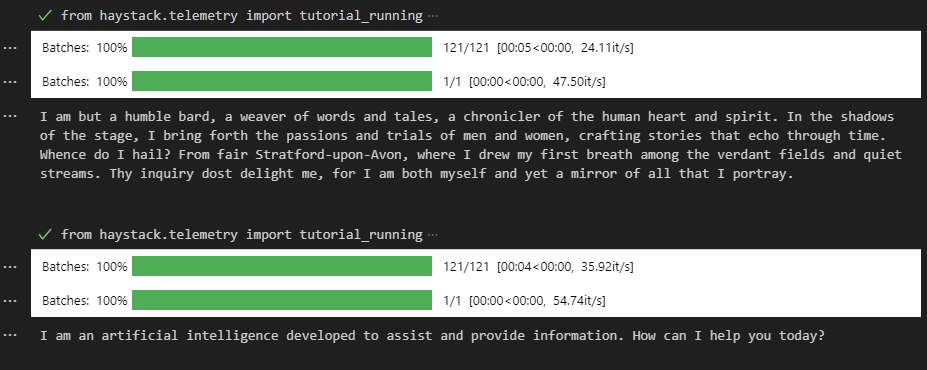

Testing if the haystack bot was using the dataset

The second response is the output when “You are William Shakespeare, the famous playwrite.” is removed from the `PromptBuilder`. This demonstrated to us that the haystack bot was not using our dataset when answering prompts.

Please see haystack bot test for the full implementation of the haystack bot prior to us scrapping it.

- **RAG Setup**: After switching to RAG, we faced challenges related to using both DeepSeek/Ollama or OpenAI API keys, as their integration and dataset handling processes required troubleshooting to achieve proper functionality.

## 5. **Final Implementation**:

After addressing these issues, we successfully integrated the RAG pipeline and OpenAI model. The chatbot now answers questions in a Shakespearean style based on context derived from the Tiny Shakespeare dataset.

Running on public URL: https://e1d93d3ff626a80b86.gradio.live/

# Colab

Please see our [Colab file](https://colab.research.google.com/drive/1mdp_t9csrccc5oJe7LRMVXTl-BEIGDR9?usp=sharing) for the full, working code and rationale.

## Example Chatbot Output

The following is an example output generated by the chatbot:

> **User Question:** *“Do you prefer an iPhone or letters?”*

**Bot Response:**

```
| Alas, fair soul, thou dost present a query
| Betwixt the modern and the age of yore
| Methinks, if I may speak with modest glee
| An iPhone’s vast capabilities I adore
| Yet letters hold such beauty, so refined
| Mayhap, for heartfelt words, they are the twine
```

We used this question to test the ability of the bot to adapt Shakespearean language to modern concepts.

## Chatbot Interface Screenshot

Below is a screenshot showing the chatbot interface with the output:

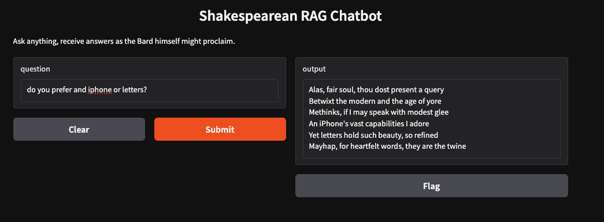

Chatbot Example

Provided is another example of the chatbot:

> **User Question:** *“Coke or Pepsi?”*

**Bot Response:**

```
| Marry, 'tis a question of great import,
| Yet simple in its essence, if I may retort.
| To choose 'twixt Coke and Pepsi fair,
| I'd say, let taste be your guide with care.
```

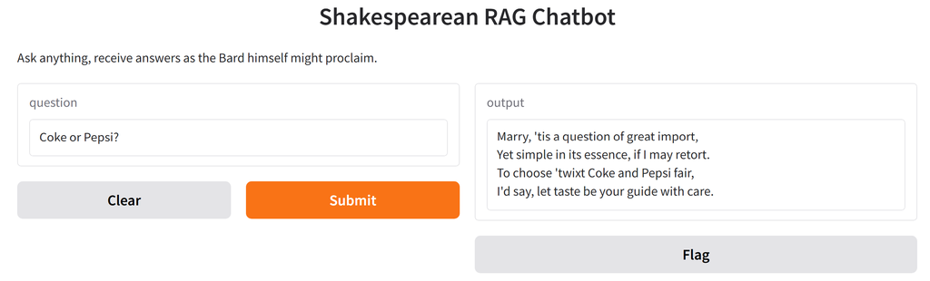

Coke or Pepsi Example

# Appendix

## Shakespeare Chatbot

### Why we’re running this on Colab?

We chose to run the chatbot code on Google Colab instead of on a local machine due to several key reasons:

**Resource Availability:**

Colab provides us free access to cloud computing resources, including GPUs and TPUs, which significantly accelerate the training and execution of models, especially when working with large datasets like the Tiny Shakespeare dataset.

This allowed us to leverage hardware that might not be available on our local machines, ensuring that the chatbot runs smoothly without resource limitations.

**Ease of Sharing:**

By using Colab, we can easily share our work with each other. This facilitates collaboration and feedback without requiring specific environment setups on individual machines.

**Pre-installed Libraries:**

Colab comes with a variety of pre-installed libraries (e.g., TensorFlow, PyTorch, Langchain) which significantly reduced the time spent on environment setup. This allowed us to focus more on the core functionality of the chatbot.

**Free Compute Time:**

Colab offers free compute resources (with limitations), which was a cost-effective choice for our project. Running resource-heavy tasks like embedding models and inference on a local machine was proving to be too difficult the Ollama - Deepseek route so this was our modification.

**No Setup Required:**

Using Colab simplified the setup process since it doesn’t require installing libraries and dependencies locally. This is especially useful when dependencies can conflict or be difficult to install on different systems.

### Failures:

Ollama and DeepSeek were not as flexible as anticipated for integrating custom datasets. Ollama’s models were designed with a specific use case in mind, making it difficult to adapt them to our needs, particularly when trying to input the Tiny Shakespeare dataset for RAG processing. DeepSeek, although powerful for search and retrieval tasks, also faced limitations when trying to integrate it with the custom data.

We had to modify our approach and workflow repeatedly to make them fit, which became time-consuming and inefficient.

Both Ollama and DeepSeek struggled with performance, especially when dealing with large datasets like Tiny Shakespeare. The retrieval process was slow, which resulted in long wait times for generating responses. This degraded the overall user experience, as the chatbot became unresponsive and inefficient during interactions.

We spent considerable time trying to get the systems to work together, but issues with embedding models, dataset handling, and retrieval tasks compounded the difficulty. Debugging these problems took longer than expected, and even after making adjustments, the system still didn’t work as smoothly as hoped.

The errors that arose from mismatched configurations and model compatibility led to the decision to abandon this setup in favor of a more straightforward approach using OpenAI’s GPT-3.5 turbo.

### Libraries installed

- openai python library
- langchain –> to integrate tools like GPT-3.5 with other components like vector databases (e.g., Chroma) and custom pipelines for more advanced tasks like RAG.
- chromadb –> for storing and querying embeddings
- gradio –> for UI
- tiktoken –> for tokenizing text

```python
# installing libraries
!pip install openai langchain chromadb gradio pandas langchain-community tiktoken --quiet
```

### Open AI version 0.28

- This version is specified because newer versions of the OpenAI Python package (v1.0.0 and above) have made changes to the API, particularly around how text generation requests are handled. The newer API versions no longer support openai.Completion.create() for chat models, which led to errors in the original code.

By specifying ==0.28, compatibility is ensured with the methods that work with GPT-3.5 and GPT-4 in the way we expected, without encountering the issues introduced in the newer versions.

```python
# specifying version of openai
!pip install openai==0.28
```

```python
import os

# API key
os.environ["OPENAI_API_KEY"] = "OMITTED"
```

```python
# uploading data file
from google.colab import files
uploaded = files.upload()
```

### Loading and Preprocessing the Data

To begin creating our chatbot, we needed to load the dataset that contained the Shakespearean text. The dataset we used is `combined_data_shakespeare.csv`, which we read into a Pandas DataFrame. Since our dataset is essentially a collection of Shakespeare’s writings, we ensured to clean up any `NaN` values by filtering them out before processing the actual text.

```python
import pandas as pd
from langchain.schema import Document
from langchain.text_splitter import RecursiveCharacterTextSplitter

# loading data
df = pd.read_csv("C:/Users/kylie/Documents/University/24-25/Sp25/INF 385T - PE/combined_data_shakespeare.csv")
documents = [Document(page_content=str(txt)) for txt in df["text"].dropna().tolist()]

# splitting the text into smaller chunks
text_splitter = RecursiveCharacterTextSplitter(chunk_size=1000, chunk_overlap=200)
chunks = text_splitter.split_documents(documents)

# limit to first 500 chunks for testing
chunks = chunks[:500]

# print # of loaded chunks
print(f"Loaded {len(chunks)} chunks.")
```

[output not shown]

### Splitting the Text into Smaller Chunks

Shakespeare’s works contain long pieces of text, so to efficiently work with it in a chatbot setting, we decided to split the text into smaller chunks. We used Langchain’s RecursiveCharacterTextSplitter to do this. The splitting ensures that no chunk exceeds 1000 characters, with a 200-character overlap between consecutive chunks. This helps maintain context when the model processes each chunk individually.

### Limiting Chunks for Testing

Since we’re still testing our system, we limited the number of chunks to the first 500. This is just for performance testing purposes and to speed up the initial trials. This way, we can quickly iterate and debug without dealing with the full dataset.

### Setting up!

#### Vector Store

Next, we initialized Chroma, which is the vector store where we will store the embeddings. Chroma allows us to efficiently retrieve relevant information later when needed.

#### Checking if Collection Exists

Before adding our embeddings to Chroma, we checked if the collection (shakespeare_modern) already existed. If it didn’t, we created a new one.

#### Generating the Embeddings

With our collection set up, we then used the embed_documents method to generate embeddings for all our text chunks in one go. This converts the text into a format that the machine learning model can process.

Finally, we added the embeddings to our Chroma collection. For each chunk of text, we stored the document (the text itself), metadata (like an ID), and the corresponding embedding.

```python
from langchain.embeddings import OpenAIEmbeddings
from langchain.vectorstores import Chroma
from chromadb.config import Settings
from chromadb import Client
from chromadb.errors import NotFoundError  # import the NotFoundError

#  initializes the embedding function using OpenAI's model
#  to transform the chunks of text into numerical vectors.
embedding_function = OpenAIEmbeddings()

# initialize Chroma client
client = Client(Settings())

# check if the collection exists and create it if not
try:
    collection = client.get_collection(name="shakespeare_modern")
except NotFoundError:
    collection = client.create_collection(name="shakespeare_modern")
    print("Collection 'shakespeare_modern' created!")

# get all embeddings in a single call
texts = [chunk.page_content for chunk in chunks]
embeddings = embedding_function.embed_documents(texts)

# add to the vector store
for idx, chunk in enumerate(chunks):
    collection.add(
        documents=[chunk.page_content],
        metadatas=[{"id": idx}],
        embeddings=[embeddings[idx]],
        ids=[str(idx)]
    )

print("embeddings stored successfully!")
```

[output not shown]

#### Setting up the Retriever

The first step is to set up the retriever. The retriever’s job is to find relevant documents from the vector store based on the query provided. We initialize it using the Chroma class, which takes the collection we created earlier (shakespeare_modern), and the embedding function.

The retrieve_context function is where we fetch relevant documents based on the question asked by the user. We retrieve these documents from the vector store using the retriever, then return their content as a string.

#### Querying OpenAI’s GPT Model

Once we have the relevant context, we need to send the query and the context to OpenAI’s GPT model to generate a response in Shakespearean style. We format the prompt to instruct the model to respond like Shakespeare, with a touch of poetic rhythm and wit.

### The RAG Pipeline

Now that we have the functions to retrieve context and query the model, we can combine them into the main RAG pipeline. This function will take the user’s question, retrieve the relevant context, and then use OpenAI to generate a Shakespearean answer.

#### Creating the Gradio Interface

To make the chatbot interactive, we use Gradio to create a simple interface. Gradio makes it easy to turn Python functions into web-based interfaces. In this case, the interface takes the user’s question as input and returns the Shakespearean response.

- Here, we define the input and output types as text, set a title and description for the interface, and specify the function (rag_pipeline) to be called when a user submits a question.

### Launching Interface!

Finally, we launch the Gradio interface so that users can start interacting with the chatbot. The share=True parameter creates a public link that anyone can use to access the chatbot, and debug=True helps us troubleshoot any issues.

This sets up everything and makes the chatbot accessible online, where anyone can ask questions and receive answers in Shakespearean style.

```python
# libraries
from langchain.vectorstores import Chroma
import gradio as gr
import re

# retrieve function: adds a print to show how many results were retrieved
retriever = Chroma(
    collection_name="shakespeare_modern",
    client=client,
    embedding_function=embedding_function
).as_retriever()

# retrieving context:
def retrieve_context(question):
    results = retriever.get_relevant_documents(question)
    print(f"Found {len(results)} relevant documents.")  # debug: show number of results
    return "\n\n".join([doc.page_content for doc in results])

# querying openai's gpt model
def query_openai_shakespeare_style(question, context):
    import openai
    prompt = f"""Thou art a poetic bard with wisdom to share. Respond to the query below as if penned by Shakespeare himself, using wit and rhythm, but keep thy reply concise and conversational.\n\nQuestion: {question}\n\nContext:\n{context}\n"""

    # updated method to use ChatCompletion (for OpenAI API v1.0 and later)
    response = openai.ChatCompletion.create(
        model="gpt-3.5-turbo",  # choose the model
        messages=[{"role": "user", "content": prompt}]  # the message content in a chat format
    )

    return response['choices'][0]['message']['content'].strip()  # Adjusted response handling

# main RAG pipeline function
def rag_pipeline(question):
    context = retrieve_context(question)
    return query_openai_shakespeare_style(question, context)

# creating the gradio interface
interface = gr.Interface(
    fn=rag_pipeline,
    inputs="text",
    outputs="text",
    title="Shakespearean RAG Chatbot",
    description="Ask anything, receive answers as the Bard himself might proclaim."
)

# launch the interface
interface.launch(share=True, debug=True)
```